# ggplot2: elegant graphics for data analysis

## purpose of this section

- Provide overview of plotting frameworks in R
- Give an introduction to ggplot2 library
- Learn how to produce various graphics with ggplot2

## software

- R version 3.4.0
- R Studio 1.0.143
- base, graphics, lattice, ggplot2, ggthemes, ggalt, ggrepel, raster

## what libraries we can use to visualize data in R?

- base plotting system
- lattice
- ggplot2
- ggvis, vegalite, plotly

## base plotting system: simple scatterplot

```r
View(cars)
plot(cars)
```

## base plotting system: line graph

```r
plot(EuStockMarkets)
```

## base plotting system: scatterplot matrix

```r
plot(iris)
```

## base plotting system: customisation

```r
plot(cars, xlab = "Speed (mph)", ylab = "Stopping distance (ft)",
     las = 1)
lines(lowess(cars$speed, cars$dist), col = "red")
title(main = "cars data")
```

## base plotting system: pros and cons

### pros

- short and simple syntax
- generic functions
- good for quick and dirty dataviz

### cons

- hard to customise
- hard to get good looking graphics
- hard to get outside-the-box plots
- no active development and new features

## lattice

```r
library(lattice)
```

## lattice: scatterplot

```r
xyplot(cars$dist ~ cars$speed)
```

## lattice: line graph

```r
xyplot(EuStockMarkets)
```

## lattice: scatterplot matrix

```r
splom(iris)
```

## lattice: pros and cons

### pros

- good for statistical graphics
- more flexible than base plotting system

### cons

- no major developments
- still hard to produce outside-the-box graphics

## ggplot2

```r
library(ggplot2)
```

## ggplot2: scatterplot

```r
ggplot(data = cars, aes(x = dist, y = speed))+
  geom_point()
```

## ggplot2: pros and cons

### pros

- based on Grammar of Graphics
- provides good defaults
- provides controls for almost every aspect of the plot
- active development

### cons

- complex syntax
- high entry treshold

## ggplot2: plot structure

```r
ggplot(data, aes(x = x, y = y, color = color, size = size), alpha = '')+
  geom_()+
  scale_x_()+
  scale_y_()+
  scale_color_()+
  scale_size_()+
  coord_()+
  facet_()+
  labs(title = '', subtitle = '', caption = '')+
  theme_minimal(base_family = '', base_size = '')+
  theme(
    legend.position = '',
    plot.background = element_rect(fill = ''),
    plot.title = element_text(),
    plot.subtitle = element_text(),
    plot.caption = element_text(),
    plot.margin = unit()
  )
```

## ggplot2: plot structure

```r
g <- ggplot(cars, aes(x = speed, y = dist))+
  geom_point()

str(g)
```

## ggplot2: data

**Data - data frame with variables to be plotted**

```r
ggplot(iris)
```

## ggplot2: aestethics

**Aesthetics - scales on which data is mapped**

```r
ggplot(iris, aes(x = Sepal.Length))
```

## ggplot2: available aesthetics

```r
ggplot2:::.all_aesthetics
```

## ggplot2: geometry

**Geometry - shapes used to represent your data**

```r
ggplot(iris, aes(x = Sepal.Length))+
  geom_histogram()
```

## ggplot2: encoding data

```r
ggplot(iris, aes(x = Sepal.Length, fill = Species))+
  geom_histogram()
```

## ggplot2: decorating data

```r
ggplot(iris, aes(x = Sepal.Length))+
  geom_histogram(fill = 'darkcyan')
```

## ggplot2: available geometries

```r
ls(pattern = '^geom_', env = as.environment('package:ggplot2'))
```

## ggplot2: geometries

```r
ggplot(presidential)+
  geom_linerange(aes(x = reorder(name, start), ymin = start, ymax = end, color = party), size = 2)
```

View(presidential)

## ggplot2: geometries

```r
ggplot(economics, aes(date, uempmed))+
  geom_line()
```

## ggplot2: position

```r
ggplot(iris, aes(x = Sepal.Length, fill = Species))+
  geom_histogram(position = 'stack')
```

```r
ggplot(iris, aes(x = Sepal.Length, fill = Species))+
  geom_histogram(position = 'dodge')
```

```r
ggplot(iris, aes(x = Sepal.Length, fill = Species))+
  geom_histogram(position = 'fill')
```

## ggplot2: positions

```r
ggplot(iris, aes(x = Sepal.Length, y = Sepal.Width, color = Species))+
  geom_point(position = 'jitter')
```

## ggplot2: available positions

```r
ls(pattern = '^position_', env = as.environment('package:ggplot2'))
```

## ggplot2: combining geometries

```r
ggplot(iris, aes(x = Sepal.Length, y = Sepal.Width, color = Species))+
  geom_point()+
  geom_smooth()
```

## ggplot2: combining geometries

```r
ggplot(iris, aes(x = Sepal.Length, y = Petal.Width, color = Species))+
  geom_point(size = 2)+
  geom_smooth(method = 'lm', se = FALSE, size = 0.5)
```

## ggplot2: combining geometries

```r
ggplot(economics, aes(date, psavert))+
  geom_area(fill = 'darkcyan', alpha = 0.2)+
  geom_line(color = 'darkcyan', size = 0.5)
```

## ggplot: combining geometries and data sources

```r
ukraine <- raster::getData(name = "GADM", country = "UKR", level = 1)
ukraine <- fortify(ukraine)

cities <- read.csv("https://raw.githubusercontent.com/andriy-gazin/population-map/master/geocoded.csv",
stringsAsFactors = F)

ggplot(ukraine)+
  geom_polygon(aes(long, lat, group = group),
               color = "#3A3F4A", fill = "#EFF2F4", size = 0.1)+
  geom_point(data = cities,
             aes(lon, lat), alpha = 0.75, size = 0.5)
```

## ggplot2: statistics

**Statistics is a way of transforming data during plotting**

```r
ggplot(iris, aes(x = Sepal.Length, fill = Species))+
  geom_bar(stat = 'count')
```

## ggplot2: statistics

```r
ggplot(mtcars)+
  geom_bar(aes(x = row.names(mtcars), y = mpg), stat = 'identity')
```

## ggplot2: statistics

```r
ggplot(diamonds, aes(x = carat, y = price))+
  geom_point()
```

```r
ggplot(diamonds, aes(x = carat, y = price))+
  geom_point()+
  stat_binhex()
```

```r
ggplot(iris, aes(x = Sepal.Width, y = Petal.Width))+
  geom_point()+
  stat_sum()
```

## ggplot2: available stats

```r
ls(pattern = '^stat_', env = as.environment('package:ggplot2'))
```

```
 [1] "stat_bin"         "stat_bin2d"       "stat_bin_2d"      "stat_binhex"      "stat_bin_hex"
 [6] "stat_boxplot"     "stat_contour"     "stat_count"       "stat_density"     "stat_density2d"
[11] "stat_density_2d"  "stat_ecdf"        "stat_ellipse"     "stat_function"    "stat_identity"
[16] "stat_qq"          "stat_quantile"    "stat_smooth"      "stat_spoke"       "stat_sum"
[21] "stat_summary"     "stat_summary2d"   "stat_summary_2d"  "stat_summary_bin" "stat_summary_hex"
[26] "stat_unique"      "stat_ydensity"
```

## ggplot2: scales

**Scale is a way of transforming data points to screen points**

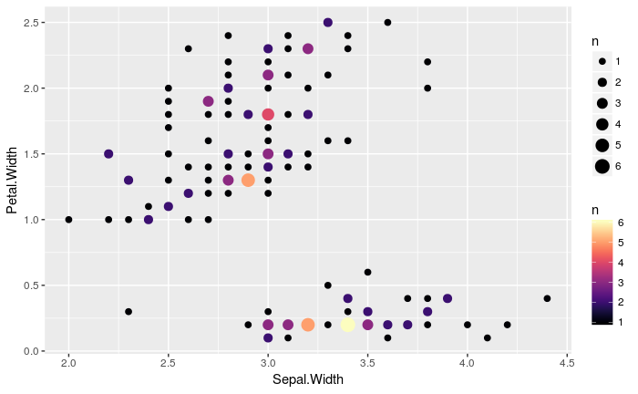

```r
ggplot(iris, aes(x = Sepal.Width, y = Petal.Width))+
  geom_count(aes(color = ..n..))+
  scale_size_area(max_size = 5) +
  viridis::scale_color_viridis(option="magma")
```

## ggplot2: scales

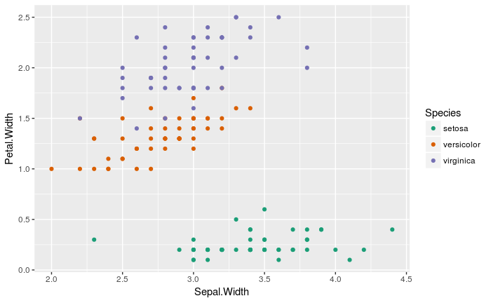

```r
ggplot(iris, aes(x = Sepal.Width, y = Petal.Width, color = Species))+
  geom_point()+
  scale_color_brewer(type = 'qual', palette = 2)
```

## ggplot2: scales

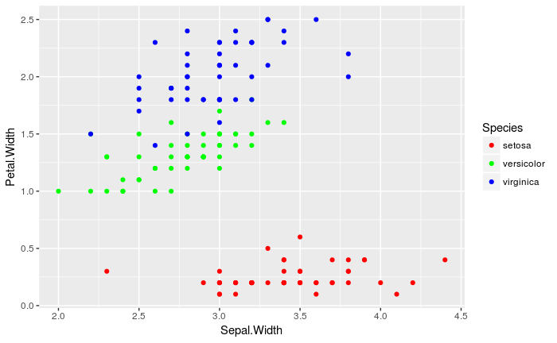

```r
ggplot(iris, aes(x = Sepal.Width, y = Petal.Width, color = Species))+
  geom_point()+
  scale_color_manual(values = c('red', 'green', 'blue'))
```

## ggplot2: scales

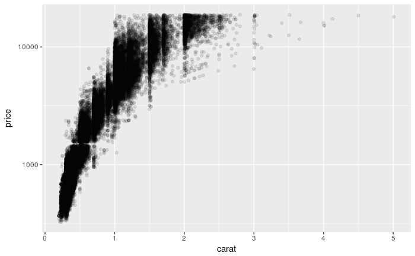

```r
ggplot(diamonds, aes(x = carat, y = price))+
  geom_point(alpha = 0.1)+
  scale_y_log10()
```

## ggplot2: scales

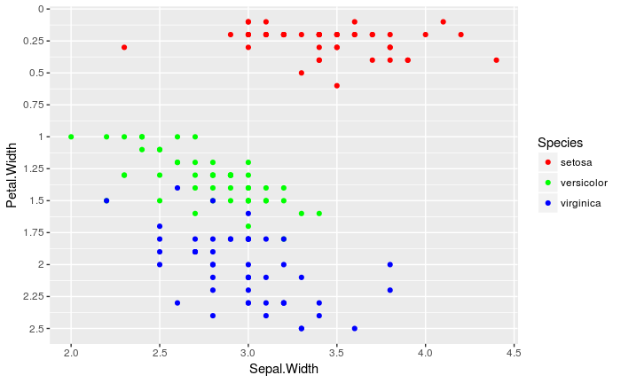

```r
ggplot(iris, aes(x = Sepal.Width, y = Petal.Width, color = Species))+
  geom_point()+
  scale_x_continuous(minor_breaks = NULL)+
  scale_y_reverse(breaks = seq(0,2.5,0.25), labels=paste(seq(0,2.5,0.25)))+
  scale_color_manual(values = c('red', 'green', 'blue'))
```

## ggplot2: available scales

```r
ls(pattern = '^scale_', env = as.environment('package:ggplot2'))
```

```
 [1] "scale_alpha"               "scale_alpha_continuous"    "scale_alpha_discrete"
 [4] "scale_alpha_identity"      "scale_alpha_manual"        "scale_color_brewer"
 [7] "scale_color_continuous"    "scale_color_discrete"      "scale_color_distiller"
[10] "scale_color_gradient"      "scale_color_gradient2"     "scale_color_gradientn"
[13] "scale_color_grey"          "scale_color_hue"           "scale_color_identity"
[16] "scale_color_manual"        "scale_colour_brewer"       "scale_colour_continuous"
[19] "scale_colour_date"         "scale_colour_datetime"     "scale_colour_discrete"
[22] "scale_colour_distiller"    "scale_colour_gradient"     "scale_colour_gradient2"
[25] "scale_colour_gradientn"    "scale_colour_grey"         "scale_colour_hue"
[28] "scale_colour_identity"     "scale_colour_manual"       "scale_fill_brewer"
[31] "scale_fill_continuous"     "scale_fill_date"           "scale_fill_datetime"
[34] "scale_fill_discrete"       "scale_fill_distiller"      "scale_fill_gradient"
[37] "scale_fill_gradient2"      "scale_fill_gradientn"      "scale_fill_grey"
[40] "scale_fill_hue"            "scale_fill_identity"       "scale_fill_manual"
[43] "scale_linetype"            "scale_linetype_continuous" "scale_linetype_discrete"
[46] "scale_linetype_identity"   "scale_linetype_manual"     "scale_radius"
[49] "scale_shape"               "scale_shape_continuous"    "scale_shape_discrete"
[52] "scale_shape_identity"      "scale_shape_manual"        "scale_size"
[55] "scale_size_area"           "scale_size_continuous"     "scale_size_date"
[58] "scale_size_datetime"       "scale_size_discrete"       "scale_size_identity"
[61] "scale_size_manual"         "scale_x_continuous"        "scale_x_date"
[64] "scale_x_datetime"          "scale_x_discrete"          "scale_x_log10"
[67] "scale_x_reverse"           "scale_x_sqrt"              "scale_x_time"
[70] "scale_y_continuous"        "scale_y_date"              "scale_y_datetime"
[73] "scale_y_discrete"          "scale_y_log10"             "scale_y_reverse"
[76] "scale_y_sqrt"              "scale_y_time"
```

## ggplot2: coordinates

**Coordinates is a way of positioning screen points**

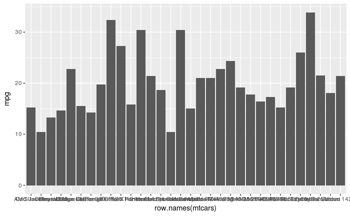

```r
ggplot(mtcars)+
  geom_bar(aes(x = row.names(mtcars), y = mpg), stat = 'identity')
```

## ggplot2: coordinates, coord_flip

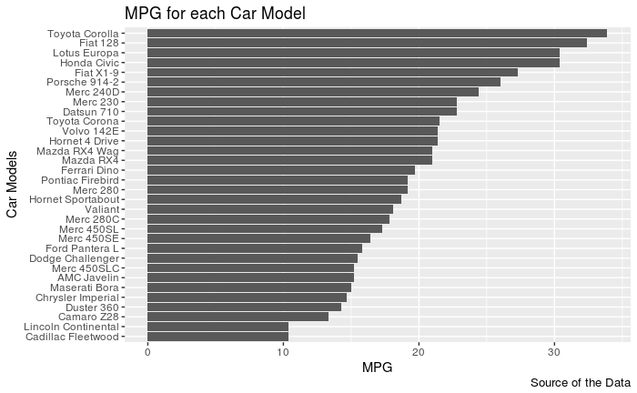

```r
ggplot(mtcars)+
  geom_bar(aes(x = reorder(row.names(mtcars), mpg), y = mpg), stat = 'identity')+
  coord_flip() + labs(x="Car Models", y="MPG", caption="Source of the Data", title="MPG for each Car Model")
```

## ggplot2: coordinates

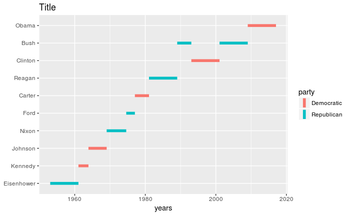

```r
ggplot(presidential)+
  geom_linerange(aes(x = reorder(name, start), ymin = start, ymax = end, color = party), size = 2)+
  coord_flip()+
  labs(y = 'years', x = NULL, title="Title")
```

## ggplot2: available coordinates

```r
ls(pattern = '^coord_', env = as.environment('package:ggplot2'))
```

```
[1] "coord_cartesian" "coord_equal"     "coord_fixed"     "coord_flip"      "coord_map"       "coord_munch"     "coord_polar"
[8] "coord_quickmap"  "coord_trans"
```

## ggplot2: facets

**Facets are rows and columns of subplot**

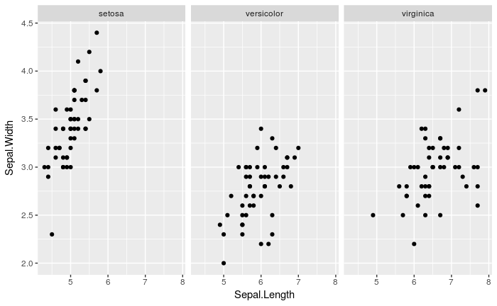

```r
ggplot(iris)+
  geom_point(aes(x = Sepal.Length, y = Sepal.Width))+
  facet_wrap(~Species)
```

## ggplot2: facets

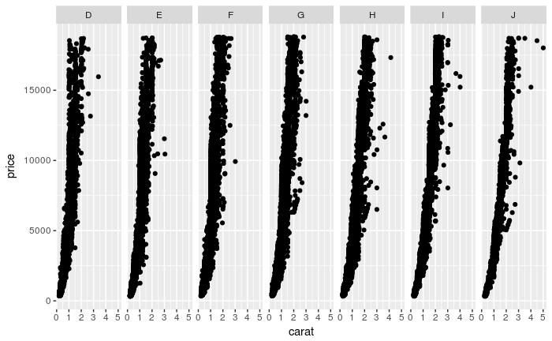

```r
ggplot(diamonds)+
  geom_point(aes(x = carat, y = price))+
  facet_wrap(~color, nrow=1)
```

## ggplot2: theme

**Theme is a way of decorating plot**

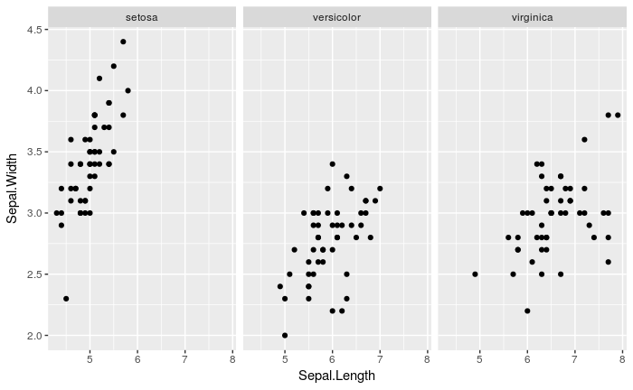

```r
ggplot(iris)+
  geom_point(aes(x = Sepal.Length, y = Sepal.Width))+
  facet_wrap(~Species)+
  theme_gray()
```

## ggplot2: built-in themes

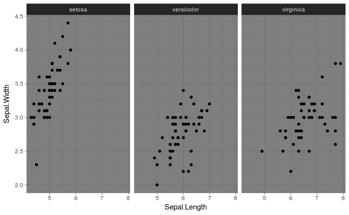

```r
ggplot(iris)+
  geom_point(aes(x = Sepal.Length, y = Sepal.Width))+
  facet_wrap(~Species)+
  theme_dark()
```

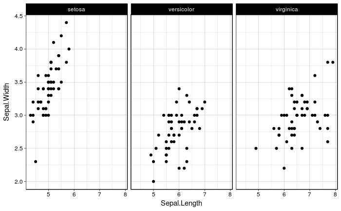

```r
ggplot(iris)+
  geom_point(aes(x = Sepal.Length, y = Sepal.Width))+
  facet_wrap(~Species)+
  theme_linedraw()
```

## ggplot2: available themes

```r
ls(pattern = '^theme_', env = as.environment('package:ggplot2'))
```

```
 [1] "theme_bw"       "theme_classic"  "theme_dark"     "theme_get"      "theme_gray"     "theme_grey"     "theme_light"
 [8] "theme_linedraw" "theme_minimal"  "theme_replace"  "theme_set"      "theme_update"   "theme_void"
```

## ggplot2: extra ggthemes package

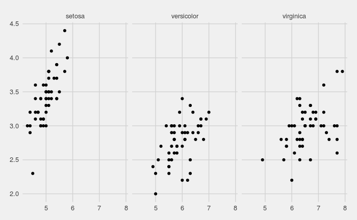

```r
library(ggthemes)
ggplot(iris)+
  geom_point(aes(x = Sepal.Length, y = Sepal.Width))+
  facet_wrap(~Species)+
  theme_fivethirtyeight()
```

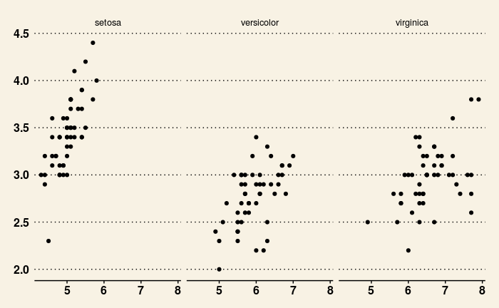

```r
library(ggthemes)
ggplot(iris)+
  geom_point(aes(x = Sepal.Length, y = Sepal.Width))+
  facet_wrap(~Species)+
  theme_wsj()
```

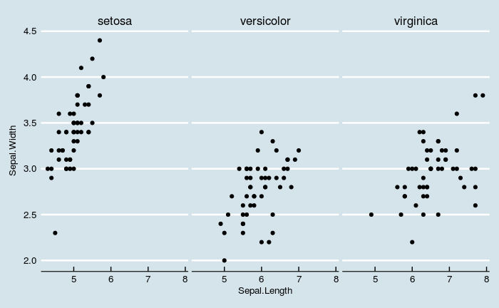

```r
library(ggthemes)
ggplot(iris)+
  geom_point(aes(x = Sepal.Length, y = Sepal.Width))+
  facet_wrap(~Species)+
  theme_economist()
```

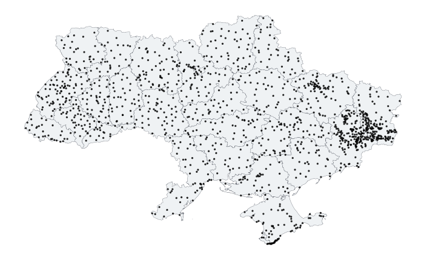

```r
ukraine <- raster::getData(name = "GADM", country = "UKR", level = 1)
ukraine <- fortify(ukraine)
cities <- read.csv("https://raw.githubusercontent.com/andriy-gazin/population-map/master/geocoded.csv",
stringsAsFactors = F)
ggplot(ukraine)+
  geom_polygon(aes(long, lat, group = group),
               color = "#3A3F4A", fill = "#EFF2F4", size = 0.1)+
  geom_point(data = cities,
             aes(lon, lat), alpha = 0.75, size = 0.5)+
  theme_map()
```

## ggthemes: available themes

```r
library(ggthemes)
ls(pattern = '^theme_', env = as.environment('package:ggthemes'))
```

```
 [1] "theme_base"            "theme_calc"            "theme_economist"       "theme_economist_white" "theme_excel"
 [6] "theme_few"             "theme_fivethirtyeight" "theme_foundation"      "theme_gdocs"           "theme_hc"
[11] "theme_igray"           "theme_map"             "theme_pander"          "theme_par"             "theme_solarized"
[16] "theme_solarized_2"     "theme_solid"           "theme_stata"           "theme_tufte"           "theme_wsj"
```

## ggplot2: custom theme

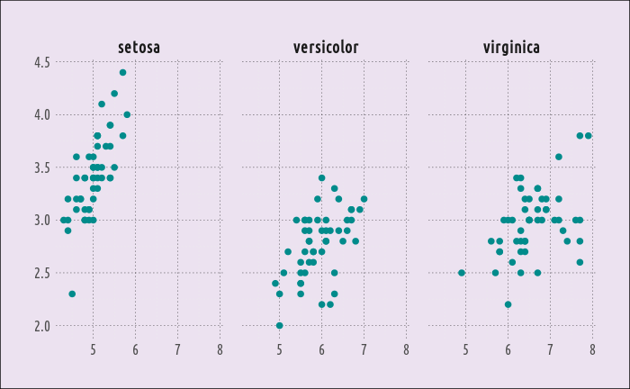

```r
library(ggthemes)
ggplot(iris)+
  geom_point(aes(x = Sepal.Length, y = Sepal.Width), color = 'darkcyan', size = 2)+
  facet_wrap(~Species)+
  theme_minimal()+
  theme(
    text = element_text(family = 'Ubuntu Condensed', size = 12),
    rect = element_rect(fill = '#ece2f0'),
    line = element_line(linetype = 'dotted', size = 0.2),
    strip.text = element_text(face = 'bold', size = rel(1.1)),
    panel.spacing.x = unit(1.1, 'lines'),
    axis.text = element_text(size = rel(1.01)),
    axis.title = element_blank(),
    panel.grid.major = element_line(color = '#000000'),
    plot.margin = unit(c(1, 1, 1, 1), 'cm'),
    plot.background = element_rect()
  )
```

## ggplot2: extensions

- ggalt
- ggraph
- ggmap
- geofacet
- viridis
- scales
- ggrepel
- gganimate
- ggmosaic
- gganimate
- ggjoy
- ggthemes
- ggthemer
- ggedit

## ggalt

```r
library(ggalt)
```

[output not shown]

## ggrepel

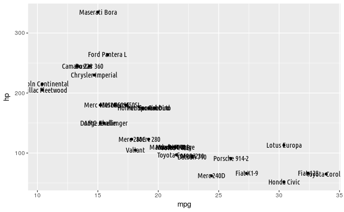

```r
ggplot(mtcars, aes(x = mpg, y = hp))+
  geom_point()+
  geom_text(aes(label = rownames(mtcars), family = 'Ubuntu Condensed'))
```

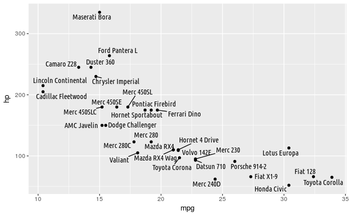

```r
library(ggrepel)
ggplot(mtcars, aes(x = mpg, y = hp))+
  geom_point()+
  geom_text_repel(aes(label = rownames(mtcars), family = 'Ubuntu Condensed'))
```

## viridis

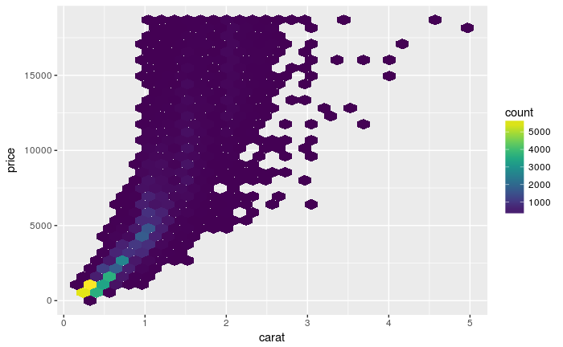

```r
library(viridis)
ggplot(diamonds, aes(x = carat, y = price))+
  geom_hex()+
  scale_fill_viridis()
```

## where to learn about ggplot2

- ggplot2 docs
- stackoverflow